# HW 6: 資料視覺化

陳立傑 B09106032 圖資系

2021-04-08 Rmd Source (for TAs)

# 1 基本題 (共 100 分)

## 1.1 視覺化死亡率 (共 40 分)

```r
# 請勿更動此 code chunk 程式碼
library(dplyr)
```

```r
library(ggplot2)
# 上週作業使用到的 titanic data
titanic <- readr::read_delim("titanic.csv",
                             delim = ";",
                             escape_double = FALSE,
                             trim_ws = TRUE)
# 上週作業 `分組摘要` 的結果
died_summary <- titanic %>%
  group_by(Sex, Pclass) %>%
  summarise(percent_survived = mean(Survived == "Yes")) %>%
  ungroup()
died_summary
```

```
#> # A tibble: 6 x 3
#>   Sex    Pclass percent_survived
#>   <chr>   <dbl>            <dbl>
#> 1 female      1            0.968
#> 2 female      2            0.921
#> 3 female      3            0.5
#> 4 male        1            0.369
#> 5 male        2            0.157
#> 6 male        3            0.135
```

此題延續上週作業關於鐵達尼號乘客死亡率的[分組摘要](https://rlads2021.github.io/hw5/index.html#分組摘要-30-分)。上方的程式碼即是上週分組摘要的答案，儲存於 `died_summary`。你的任務是使用 `ggplot2` 將 `died_summary` 繪製成此長條圖:

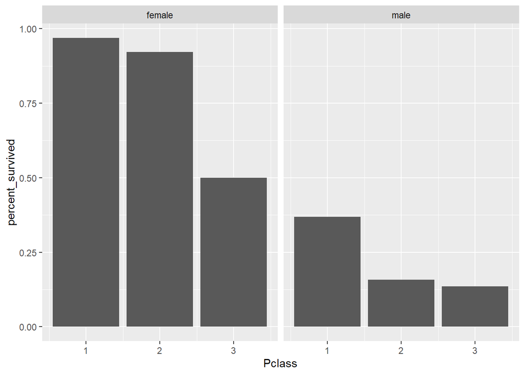

```r
# Write your code here

library(ggplot2)
ggplot(died_summary) +
  geom_bar(aes( x = Pclass , y = percent_survived), stat = "identity") +
  facet_wrap(~Sex)
```

1. 如果不知道如何下手，請先閱讀 [R for Data Science 第三章](https://r4ds.had.co.nz/data-visualisation.html)
2. 你應該會使用到 `geom_bar()` 或是 `geom_col()`
3. 你應該會使用到 `facet_wrap()`
4. 輸出結果應與下圖相同：

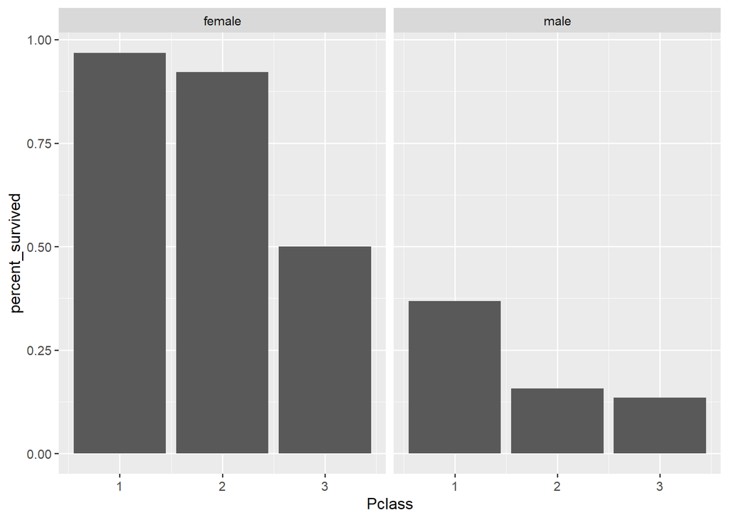

輸出結果應要與此圖相同

## 1.2 自己的資料自己畫 (共 50 分)

請自行尋找一份資料 (不得使用 `titanic.csv` 或內建資料)，將其放在此次作業的 repo 並命名為 `mydata.csv` (副檔名請根據自己的資料而定, e.g., 若為 tab 分隔檔，請命名為 `mydata.tsv`)。你的任務是將這份資料讀入並使用 ggplot2 視覺化這份資料。

1. (10 分) **資料讀取與清理**  
   將 `mydata.csv` 讀入並進行資料清理 (如果需要的話)，以利接下來的資料視覺化
2. (30 分) **資料視覺化**  
   請依這份資料的特性以及你想觀察的現象，對這份資料進行視覺化。依據你的喜好，你可以畫任意多張圖，但**其中一張圖裡「必須」使用到 2 種或 2 種以上的 `geom_*()` 函數** (助教也只會依據這張圖評分)。這些 `geom_*()` 的使用需合理。例如，下方的例子雖然仍畫得出圖，但顯然是不合理的，這種情況將不予給分：

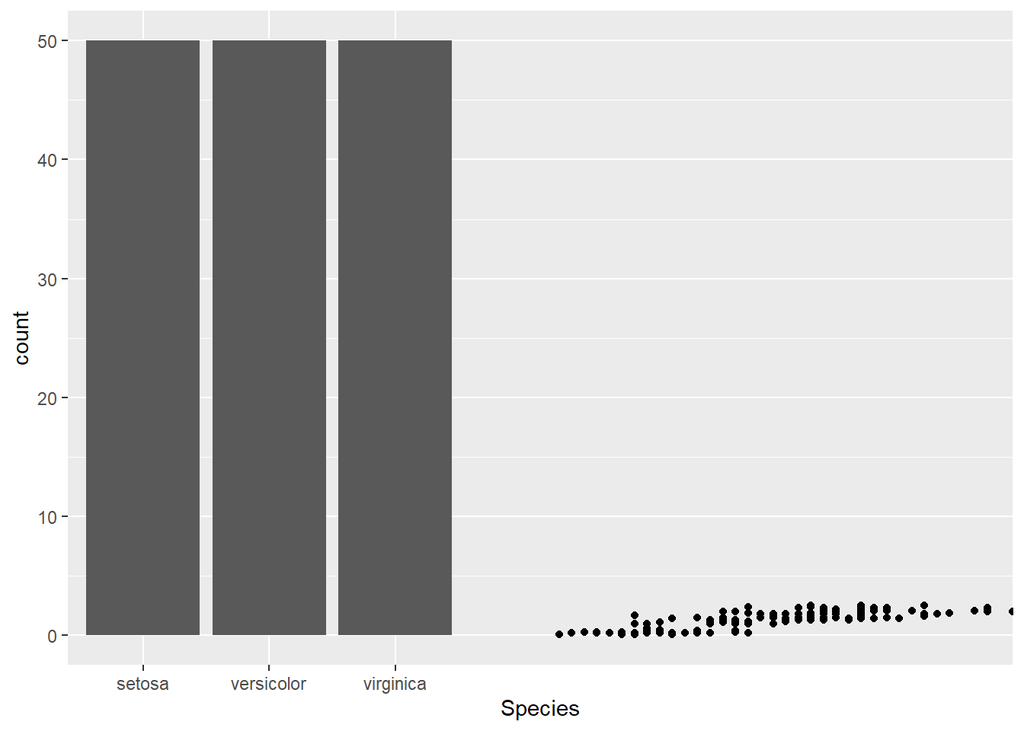

   ```r
   ggplot(iris) +
     geom_bar(aes(x = Species)) +
     geom_point(aes(Sepal.Length, Petal.Width))
   ```

3. (10 分) **Tweak the plot**  
   請依據你的個人偏好「修改」於 `2.` 所繪製出來的圖。例如，你可以使用某個 [`coord_*()`](https://ggplot2.tidyverse.org/reference/index.html#section-coordinate-systems) 將圖的 x、y 軸對調；使用其它的[風格](https://ggplot2.tidyverse.org/reference/index.html#section-themes)；或是修改與新增圖的[座標軸名稱與標題](https://ggplot2.tidyverse.org/reference/index.html#section-scales)等。
   - 評分標準：你只要合理地使用到 https://ggplot2.tidyverse.org/reference 當中 [Scales](https://ggplot2.tidyverse.org/reference/index.html#section-scales), [Coordinate systems](https://ggplot2.tidyverse.org/reference/index.html#section-coordinate-systems) 或是 [Themes](https://ggplot2.tidyverse.org/reference/index.html#section-themes) 這三個段落之內的**任意一個**函數即可得分。

若覺得題目說明不夠清楚，可以參考此題的範例。

### 資料讀取與清理 (10 分)

```r
# Write your code here
# 請務必印出 data frame

library(readr)
books <- read.csv("C:/Users/LIT JIE/OneDrive/Desktop/hw6/mydata.csv")
books
```

```
#>                                                                                                                            Name
#> 1                                                                                                 10-Day Green Smoothie Cleanse
#> 2                                                                                                             11/22/63: A Novel
#> 3                                                                                       12 Rules for Life: An Antidote to Chaos
#> 4                                                                                                        1984 (Signet Classics)
#> 5                                                            5,000 Awesome Facts (About Everything!) (National Geographic Kids)
#> 6                                                                                 A Dance with Dragons (A Song of Ice and Fire)
#> 7                            A Game of Thrones / A Clash of Kings / A Storm of Swords / A Feast of Crows / A Dance with Dragons
#> 8                                                                                                A Gentleman in Moscow: A Novel
#> 9                                                                                 A Higher Loyalty: Truth, Lies, and Leadership
#> 10                                                                                                    A Man Called Ove: A Novel
#> 11                                                                                                    A Man Called Ove: A Novel
#> 12                               A Patriot's History of the United States: From Columbus's Great Discovery to the War on Terror
#> 13                                                                                                      A Stolen Life: A Memoir
#> 14                                                                                             A Wrinkle in Time (Time Quintet)
```

[output cut: 1638 more lines]

### 資料視覺化 (30 分)

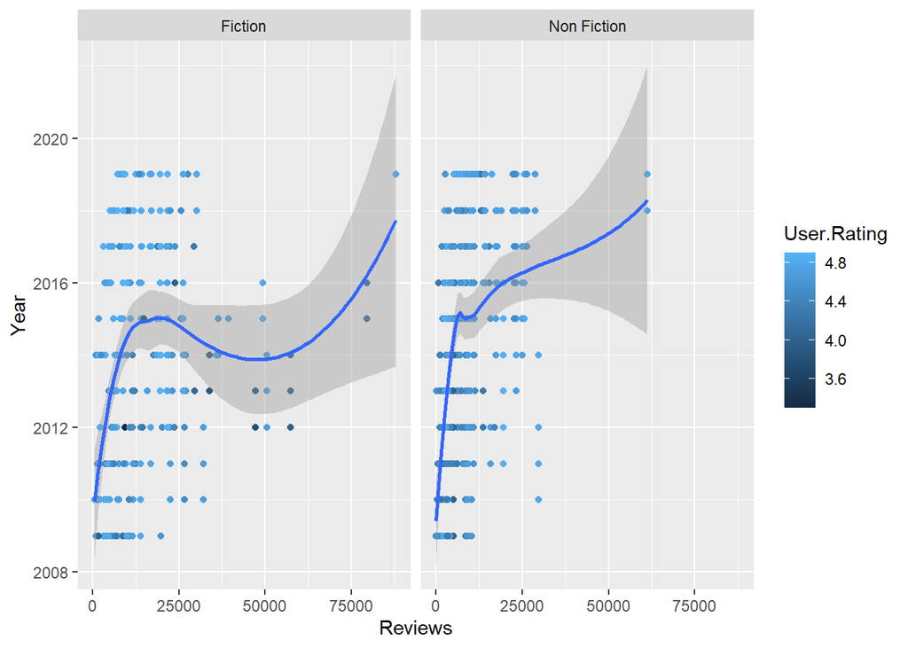

```r
# Write your code here
# 請務必印出圖片
library(ggplot2)
ggplot(data = books, aes(x = Reviews, y = Year, colour = User.Rating))+
  geom_point()+
  geom_smooth()+
  facet_wrap(~Genre)
```

### Tweak the plot (10 分)

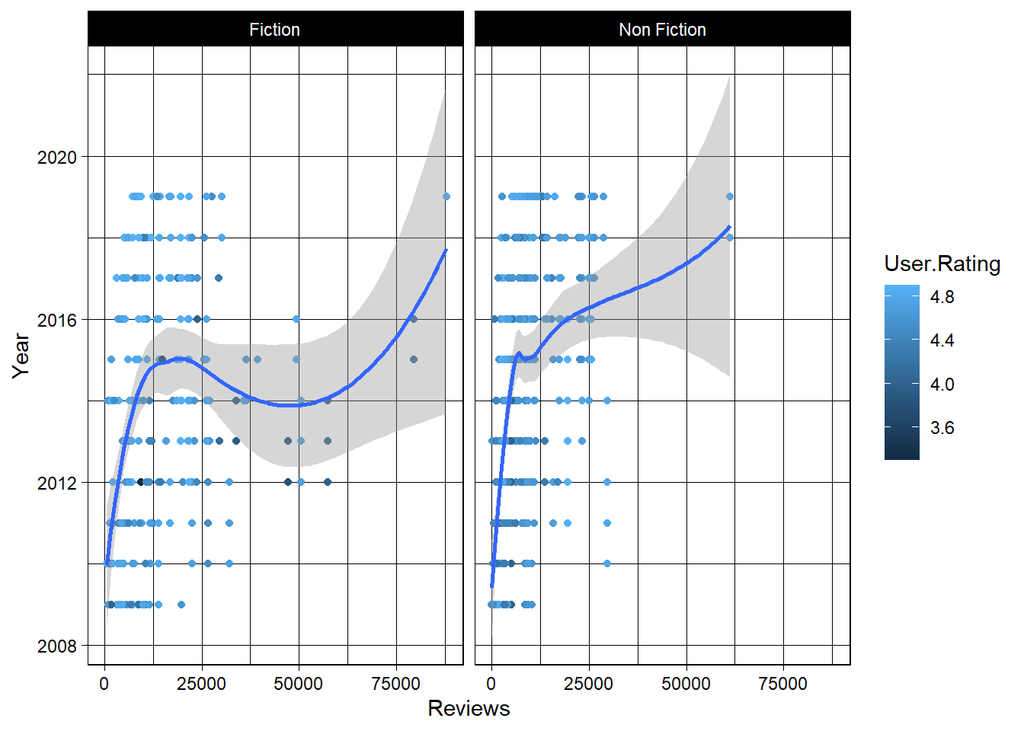

```r
# Write your code here
library(ggplot2)
ggplot(data = books, aes(x = Reviews, y = Year, colour = User.Rating))+
  geom_point()+
  geom_smooth()+
  facet_wrap(~Genre)+
  theme_linedraw()
```

## 1.3 線上實習課調查問卷 (10 分)

請填寫[此份課程調查問卷](https://forms.gle/KKdkSSU4HSARaQ7H7)，並將下方 `我，未命名，已完成問卷填答` 內的 `未命名` 更改為自己的姓名：

> 我，陳立傑，已完成問卷填答

# 2 進階選答題 (共 20 分)

請使用 `ggplot2` 中的 `mpg` 這份資料繪製圖表。 (可使用 `?mpg` 查看這份資料的說明)

1. 請以顏色標示「車種」 `class` 是否為 **SUV**。 (6分)
2. 請繪製「引擎排氣量」 `displ` 和「每加侖可高速行駛英里」 `hwy` 的線性回歸線，並將「年分」 `year` 以不同線條類型標示，且不須繪製信心區間 (請使用 `geom_smooth()`)。(6分)
3. 請以黑色直線標示「引擎排氣量」 `displ` 的平均值。(6分)
4. 請將顏色和線條類型的圖例名稱分別設定為 `SUV` 和 `Year` 。(2分)
- 本題輸出結果應如下圖：

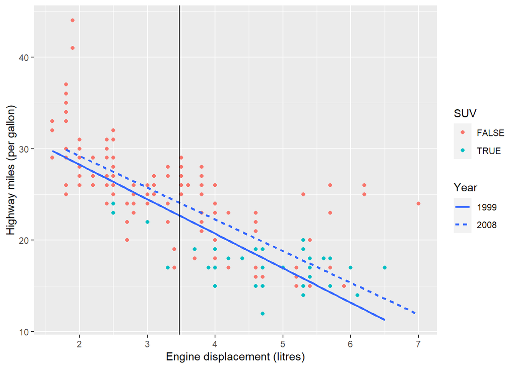

進階題輸出結果

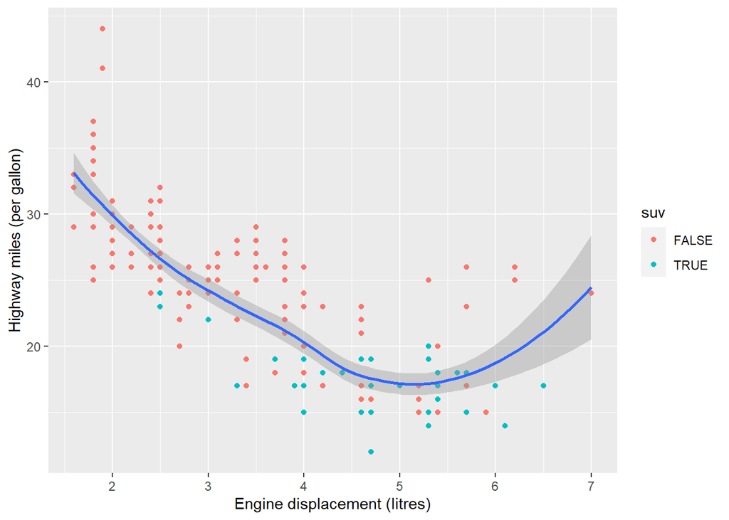

```r
# Modify the code below
suv <- if_else(mpg$class == "suv","TRUE","FALSE")

library(ggplot2)
ggplot(data = mpg, mapping = aes(displ, hwy)) +
  geom_point(aes(colour = suv)) +
  geom_smooth() +
  labs(x = "Engine displacement (litres)", y = "Highway miles (per gallon)")
```